# Predicting GPA and Interpreting Results

Brandon Chan, Lucas Duncan, Owen Macgowan

2025-03-07

# 1 Executive Summary and Contents

| Index | Category | Method |
| --- | --- | --- |
| 1 | Introduction and Tidying | Importing, Wrangling and Encoding |
| 2 | Unsupervised Learning and Analysis | PCA and Clustering |
| 3 | Preprocessing | Variable Selection |
| 4 | Supervised Regression | Linear and Non-Linear Regression |
| 5 | Supervised Linear Classification | LDA and Logistic Regression |
| 6 | Supervised Non-Linear Classification | Tree-Based Methods and Support Vector Machines |
| 7 | Deep Learning | Neural Network |
| 8 | Conclusion and Future Research | Written Description |

# 2 Introduction and Preprocessing

By analyzing different factors that contribute to student performance, we aim to provide insight into how institutions can improve educational and environmental factors that foster student success. This is an issue that we can relate to directly. As students ourselves, we understand that success in academics is influenced by several factors that include preparation and ability, but go beyond to include factors outside of school.

## 2.1 The Student Performance Dataset

The dataset consists of attributes that may have an impact on performance in school. There are academic variables that include grades in different subjects and other variables like ethnicity, gender, and economic status of the student families. There are options for regression and classification problems with this data. With the given variables, GPA seems like the most likely response variable to represent student performance. After some wrangling, gpa_letter, gpa, and gpa_desirable represent different forms of the possible response variable to predict.

We start by cleaning our data; renaming columns for clarity, converting column types, generating attributes, and filtering rows and columns. We filter duplicate rows, and interpolate using column means for missing numerical variables, we fill variables where possible to fix inconsistencies between gpa and gpa_letter, then drop the remaining rows missing key factor variables.

| is_male | race_ethnicity | parent_education | has_subsidized_lunch | has_prepared | recent_math_score | recent_writing_score | recent_science_score | gpa_letter | gpa | gpa_desirable |
| --- | --- | --- | --- | --- | --- | --- | --- | --- | --- | --- |
| 1 | D | some college | 1 | 1 | 89 | 85 | 26 | C | 59.5 | TRUE |
| 1 | B | high school | 1 | 0 | 65 | 67 | 96 | A | 82.0 | FALSE |

## 2.2 Variable Distributions

We now want to get more familiar with our data, looking first at the numeric columns, we observe all seem approximately normal, which is to be expected given their nature. We note they all seem to be within acceptable range (0,100). We next analyze the boolean columns, none of which have one boolean option which dominated the data. Notably there seems to be an approximately equal number of males and females, which is a good sign that our sample is proportional to an entire group. Finally we analyze the true factors, education and race, and once again no one factor dominates the data, while factors are not exactly normally distributed, nor should they be, there is healthy variation between rows with no one factor representing too few rows.

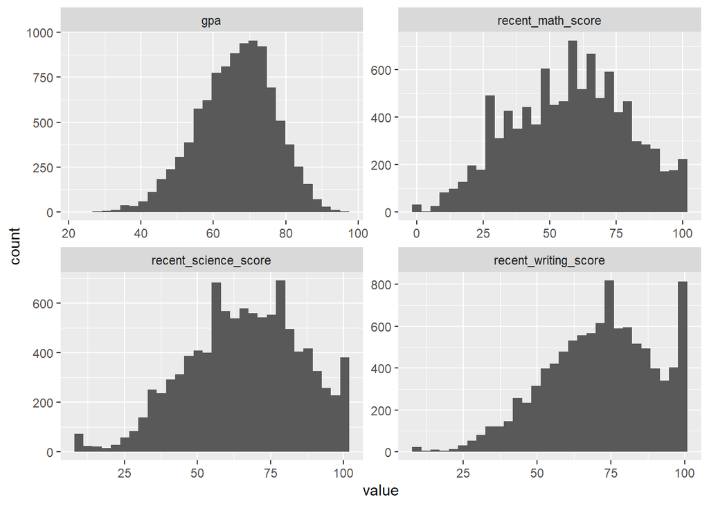

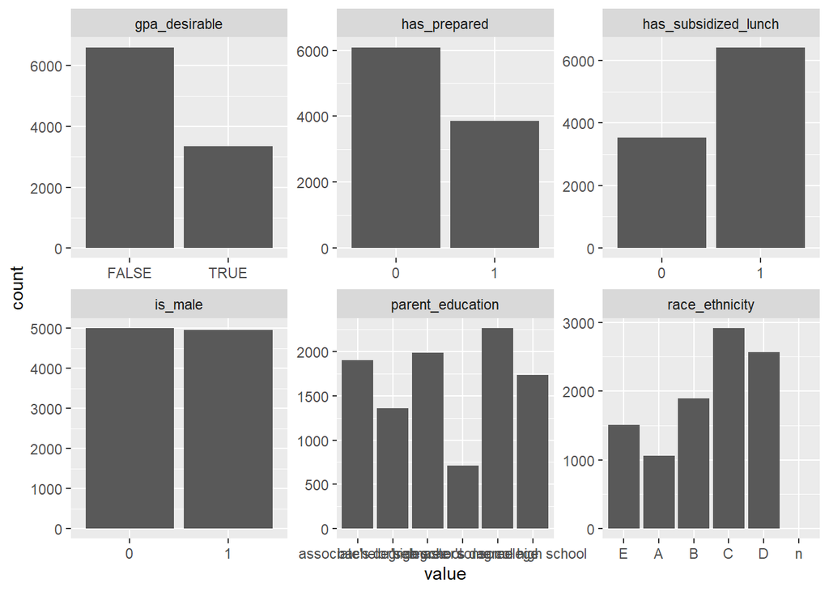

## 2.3 Encoded Data Frame

From here, our next step in processing is to convert our factor variables into one hot notation to be used in predictive models. We modify both parent_education and race, as well as converting boolean factor variables into integers for use in models.

| is_male | has_subsidized_lunch | has_prepared | recent_math_score | recent_writing_score | recent_science_score | gpa_letter | gpa | gpa_desirable | race_ethnicityE | race_ethnicityA | race_ethnicityB | race_ethnicityC | race_ethnicityD | race_ethnicityn | parent_educationbachelor’s degree | parent_educationhigh school | parent_educationmaster’s degree | parent_educationsome college | parent_educationsome high school |
| --- | --- | --- | --- | --- | --- | --- | --- | --- | --- | --- | --- | --- | --- | --- | --- | --- | --- | --- | --- |
| 1 | 1 | 1 | 89 | 85 | 26 | C | 59.5 | TRUE | 0 | 0 | 0 | 0 | 1 | 0 | 0 | 0 | 0 | 1 | 0 |
| 1 | 1 | 0 | 65 | 67 | 96 | A | 82.0 | FALSE | 0 | 0 | 1 | 0 | 0 | 0 | 0 | 1 | 0 | 0 | 0 |

## 2.4 Handling Multi-Collinearity

To deal with the multicollinearity problem, we had to remove the reference column for the race_ethnicity variable to get appropriate VIF scores.

|  | VIF.Original | VIF.with.Dropped.Ref. |
| --- | --- | --- |
| is_male | 1.187348 | 1.186748 |
| has_subsidized_lunch | 1.012943 | 1.012655 |
| has_prepared | 1.004852 | 1.004631 |
| recent_math_score | 1.092842 | 1.092812 |
| recent_writing_score | 1.082337 | 1.082212 |
| recent_science_score | 1.029769 | 1.029602 |
| race_ethnicityE | 321.711292 | 1.526049 |
| race_ethnicityA | 238.054413 | 1.827008 |
| race_ethnicityB | 385.188891 | 2.071960 |
| race_ethnicityC | 517.000750 | 2.004011 |

# 3 Data Exploration with Unsupervised Methods (PCA and Clustering)

Before attempting to make any conclusive analysis, we want to get a better understanding of the data and relationships between variables. We start this process with unsupervised learning to understand variables that cause significant variance and groupings of observations.

## 3.1 PCA: Generating and Visualizing Principle Components

We begin exploration by generating the principal components to create a 2-dimensional visualization. The first 2 principal components represent uncorrelated linear combinations that capture the most variance in the data. We plot them to see if any patterns emerge.

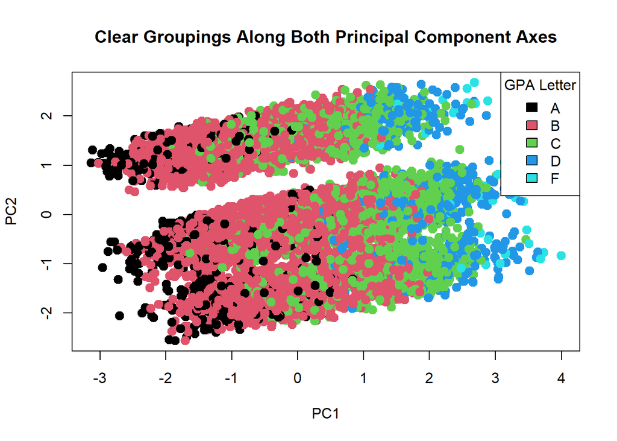

## 3.2 K-means Clustering: Ideal Number of Clusters

In order to check our theory on the distinct groupings of the first two principal components, we will employ k-means clustering. But first, we need to determine the optimal number of clusters to effectively show potential classes.

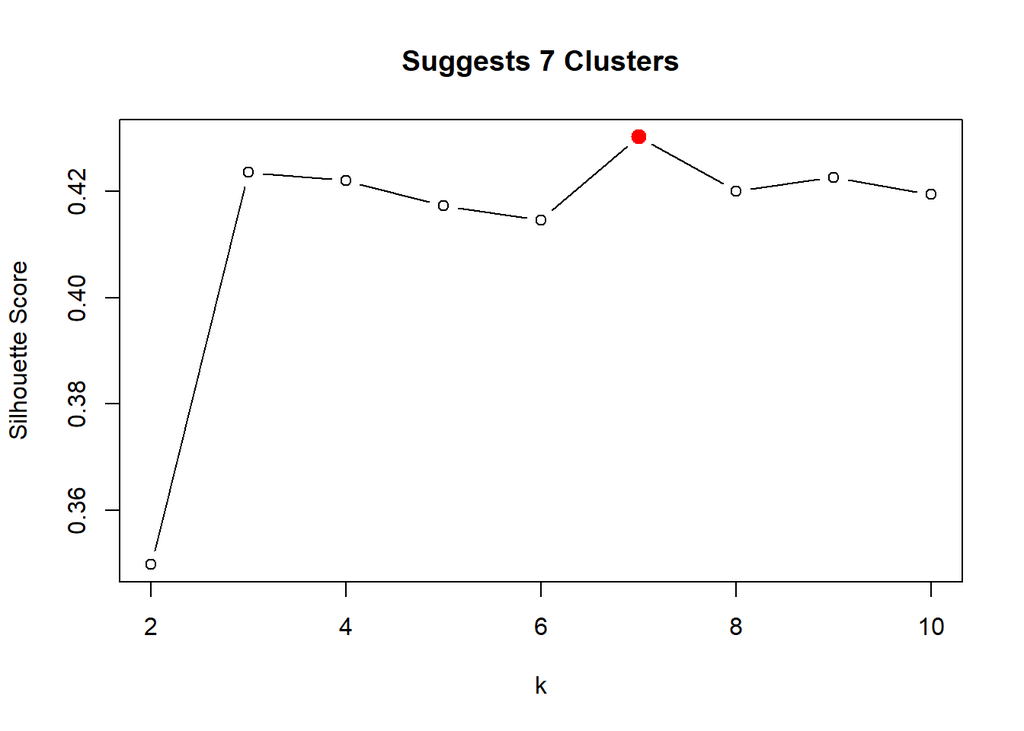

## 3.3 K-Means Clustering on First 2 Principal Components

We color the points on the same principal component graph, this time by the cluster that they belong to.

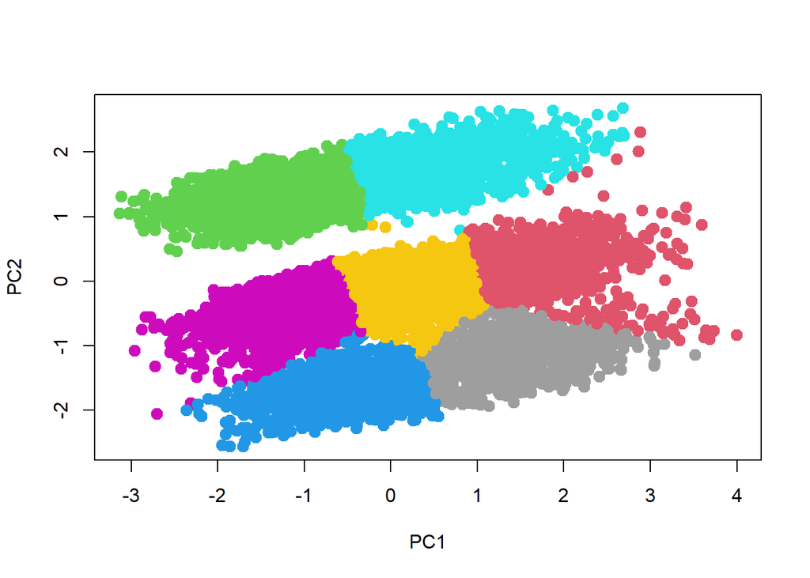

## 3.4 Impact of Variables on the First Principle Component

We wanted to take a closer look at specific features in addition to the overall structure of the data and principal components. So we took the top ten largest loadings (coefficients) of the first principal component. The goal is determine which variables are responsible for variance within the feature set.

| Variable Names | PC1 Loading |
| --- | --- |
| is_male | 0.5916517 |
| recent_math_score | -0.4443770 |
| recent_writing_score | -0.4309222 |
| recent_science_score | -0.3182190 |
| race_ethnicityC | -0.1935130 |
| has_subsidized_lunch | -0.1715074 |
| parent_educationsome high school | -0.1561814 |
| race_ethnicityD | 0.1520213 |
| race_ethnicityA | -0.1132013 |
| parent_educationmaster’s degree | 0.1060432 |

## 3.5 Proportion of Variance Explained (PVE)

Only the first principal component was analyzed, and other principal components may tell very different stories about which features may be significant. We show how much each additional principal component contributes to the proportion of variance explained:

| Number of Principal Components | PVE | Cumulative PVE |
| --- | --- | --- |
| 1 | 0.0922817 | 0.0922817 |
| 2 | 0.0814607 | 0.1737425 |
| 3 | 0.0764538 | 0.2501962 |
| 4 | 0.0740256 | 0.3242218 |
| 5 | 0.0733677 | 0.3975896 |
| 6 | 0.0704879 | 0.4680774 |
| 7 | 0.0685702 | 0.5366476 |
| 8 | 0.0673422 | 0.6039899 |
| 9 | 0.0631607 | 0.6671506 |
| 10 | 0.0599938 | 0.7271443 |

Additional principal components contribute significantly to higher PVE. The first principal component does not contribute to much of the variance explained and the second principal component does not increase it significantly either. We interpret this to mean that there are many notable linear combinations of features rather than a one that significantly explains variance the feature space.

## 3.6 Partial Least Squares Prediction for GPA

Our analysis on the principal components is predicated on the assumption that they having meaning in relation to evaluating academic performance. We evaluate this by using partial least squares to predict GPA.

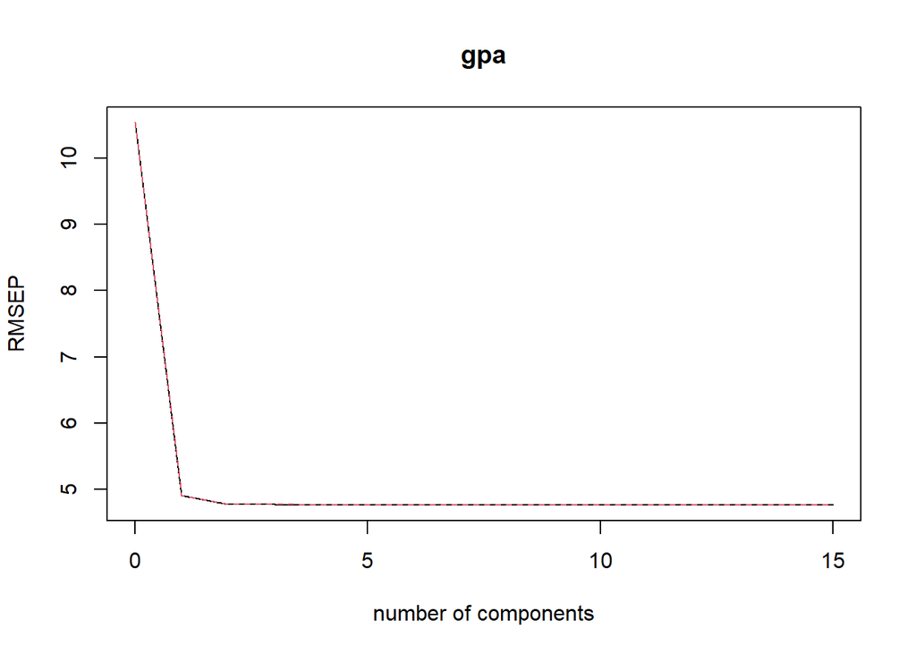

3 components appears optimal based on the PVE and plot.

| RMSE |
| --- |
| 4.729063 |

We will compare the error with other methods later in the analysis to determine how effective the principal component are at predicting GPA, our measure for academic performance.

# 4 Variable Selection for Supervised Methods

Before proceeding to predict GPA with supervised linear methods, we want to ensure that predictor variables used are relevant. It could also be helpful to analyze which predictors contribute to academic success. This will help to determine what factors institutions and individuals can improve to aid in academics.

## 4.1 Evaluating Criterion for Best Subset Selection

Since the dataset is not too large (~10000 rows), we feel that using best-subset selection is computationally feasible and is the optimal method for variable selection. 3 types of evaluation criterion are employed to determine the ideal variables; AIC, BIC, and adjusted R-squared.

```
## Reordering variables and trying again:
```

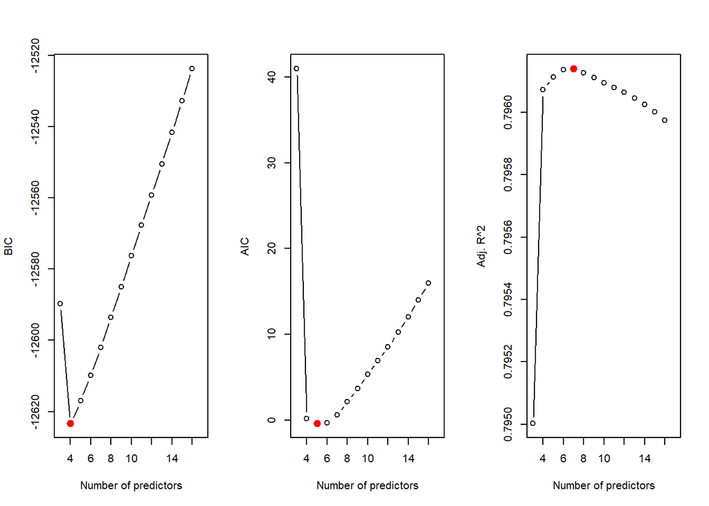

The best number of predictors appears different but fairly similar given each criterion. BIC heavily penalizes additional variables, so it is expected to favour a lower number of variables. AIC appears to prefer one more variable and few more variables are favoured with $R^2_{adj}$.

## 4.2 Ideal Number of Variables for Each Criterion

| Best_BIC | Best_Cp | Best_Adjusted_Rsq |
| --- | --- | --- |
| 4 | 5 | 7 |

Since BIC heavily penalizes extra predictors and adjusted $R^2_{adj}$ appears to be more lenient, we choose to use 6 predictors, a value in the middle.

## 4.3 Names of Ideal Predictors

The following variables contribute the most according to best subset selection:

| ChosenPredictors |
| --- |
| is_male |
| has_prepared |
| recent_math_score |
| recent_writing_score |
| recent_science_score |
| parent_educationsome high school |

We update train and test sets to only includes these predictors.

# 5 Regression for Identifying Important Predictors of Academic Success

With the selected variables, we can now test how well they predict academic performance measured in GPA. We start by training supervised regression models to predict the GPA score.

## 5.1 Choosing the Most Effective Linear Method

The base linear regression model, as well as linear models with LASSO and Ridge regularization are created and compared.

| Loss Type | Unregularised Linear | LASSO | Ridge |
| --- | --- | --- | --- |
| RMSE | 4.714030 | 4.714620 | 4.738995 |
| MAE | 3.874895 | 3.876661 | 3.899528 |

Interestingly, the unregularized model outperforms LASSO and Ridge regression. This may be because we performed regularization after variable selection, so irrelevant predictors were already filtered out. Additional penalties on predictors probably only interfered with making the best predictions that minimize SSE.

## 5.2 Extracting Insight And Evaluating Chosen Linear Method

Before making conclusive analysis, we want to ensure that the model is predicting accurately on test data.

### 5.2.1 Accuracy Within 10%

Since the linear regression model only predicts continuous values, it wouldn’t make sense to calculate accuracy directly, but we still want to ensure that the model is accurate. We resolve this by predicting how frequently predictions are within 10 points of the true GPA.

```
## [1] "Accuracy within 10 GPA points:  0.977409638554217"
```

The vast majority of predictions are within 10 points of the true GPA, so we feel that analysis on the impact of each attribute will be meaningful.

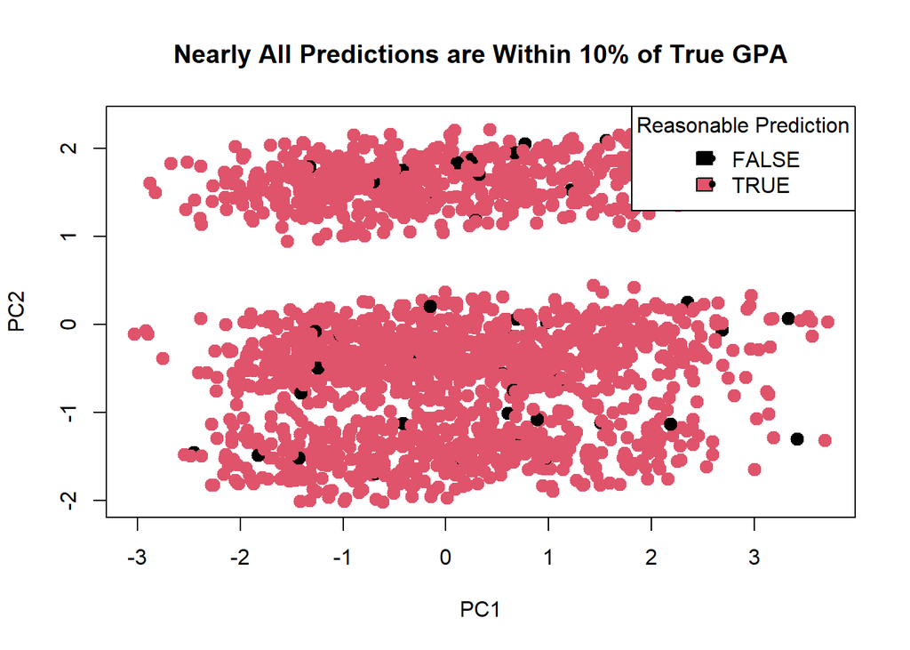

Since the model is fairly accurate at predicting GPA, we feel that analyzing coefficients directly can provide insight into how each predictor contributes to success.

```
##                      (Intercept)                          is_male
##                       15.4983645                        0.7684885
##                     has_prepared                recent_math_score
##                        0.1515244                        0.2453538
##             recent_writing_score             recent_science_score
##                        0.2604180                        0.2662900
## parent_educationsome_high_school
##                        0.2246999
```

Of the encoded variables, gender appears to be the most significant based on the raw coefficient, followed by parent education and preparation. These values suggest that societal factors meaningfully impact academic success, potentially because of different educational opportunities. Pure academic scores appear to contribute similarly to each other. This may be because students successful in one subject tend to be successful overall.

## 5.3 Non-linear Regression: GAM

Although the linear model was successful, but there remains a possibility that prediction is more accurate with non-linear transformations applied to variables. We employ a generalized additive model with splines determined by cross-validation.

## 5.4 Model Comparison

At this point we have the best supervised linear, non-linear, and unsupervised models. By comparing each of them, we hope to obtain the best one and to understand why it performed the best. Once the model is understood, we will attempt to relate the model to real-world academic performance.

| Measurement | GAM | LinearModel | PLS |
| --- | --- | --- | --- |
| RMSE | 4.7125372 | 4.7140299 | 4.7290633 |
| R2 | 0.8056238 | 0.8055003 | 0.8042583 |

The generalized additive model performs the best in terms of RMSE. Non-linear splines applied to predictors appear to improve the model, indicating that GPA is not best determined by a linear combination of features. The PLS predictions formed by the first 3 principal components perform slightly worse, though not by a drastic margin. Reducing dimensionality or the number of variables seems to help the model in all methods.

Based on the results of applying regression to predict GPA, societal and educational factors both contribute to academic success.

# 6 Linear Classification for Evaluating Predictive Accuracy of GPA Predictors

The regression models allowed us show importance within the model of specific variables by analyzing coefficients, but we were unable to compute easily interpretible metrics such as accuracy directly. The purpose of our analysis is to translate our findings to the real world, and we think that a classification perspective will provide more interpretable results. Our goal in this section is to determine whether a linear decision boundary can differentiate between students having a desirable GPA.

## 6.1 LDA Model

The first classification method we attempt is linear discriminant analysis. We train it using the same predictors determined by variable selection.

We plot the distribution of LD1 discriminant scores to look for skew or multimodal properties.

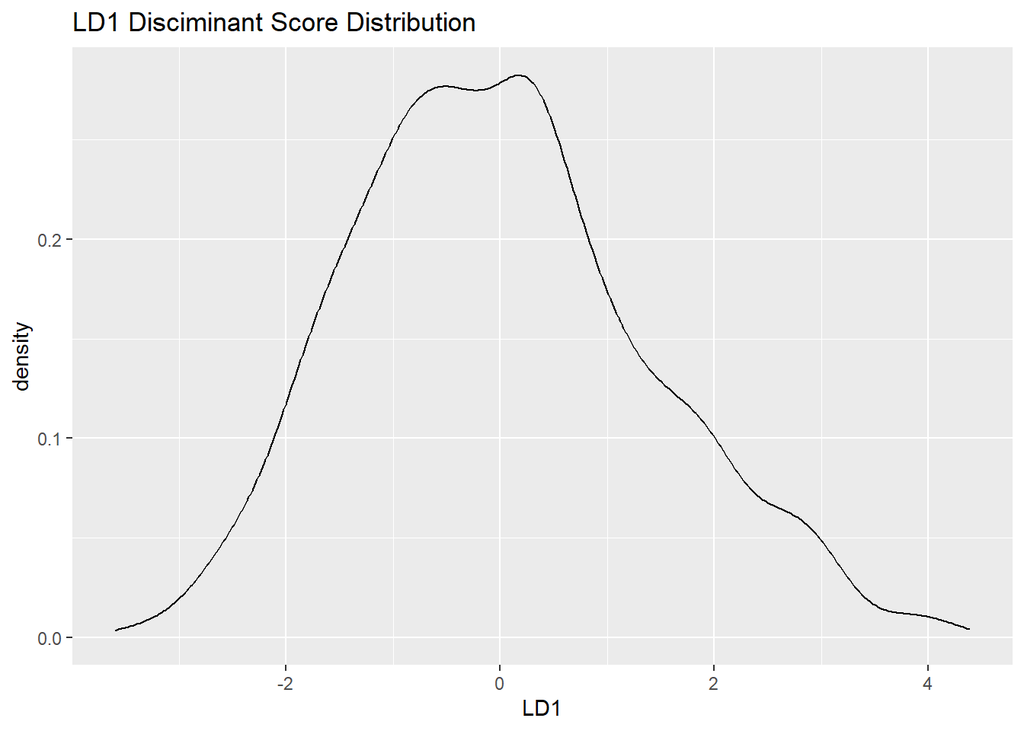

There appears to be a multimodal peak representing each class although it is very subtle. The distribution also appears to have a slight skew right. We interpret these properties to mean that there is a noticeable distinction between classes and there are more extreme large discriminant scores. This could mean that some students are strongly predicted to have a good GPA given the predictors.

We evaluate the LDA model with a confusion matrix and related metrics.

### 6.1.1 Confusion Matrix

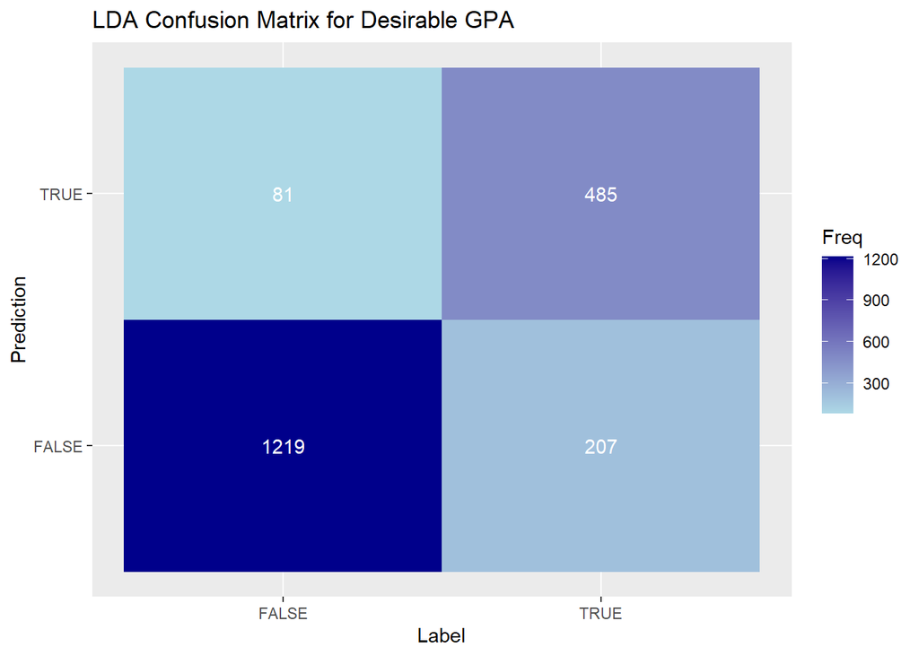

### 6.1.2 Metrics

| Metric | Score |
| --- | --- |
| Accuracy | 0.8554217 |
| Sensitivity | 0.9376923 |
| Specificity | 0.7008671 |

## 6.2 Logistic Model

### 6.2.1 Confusion Matrix

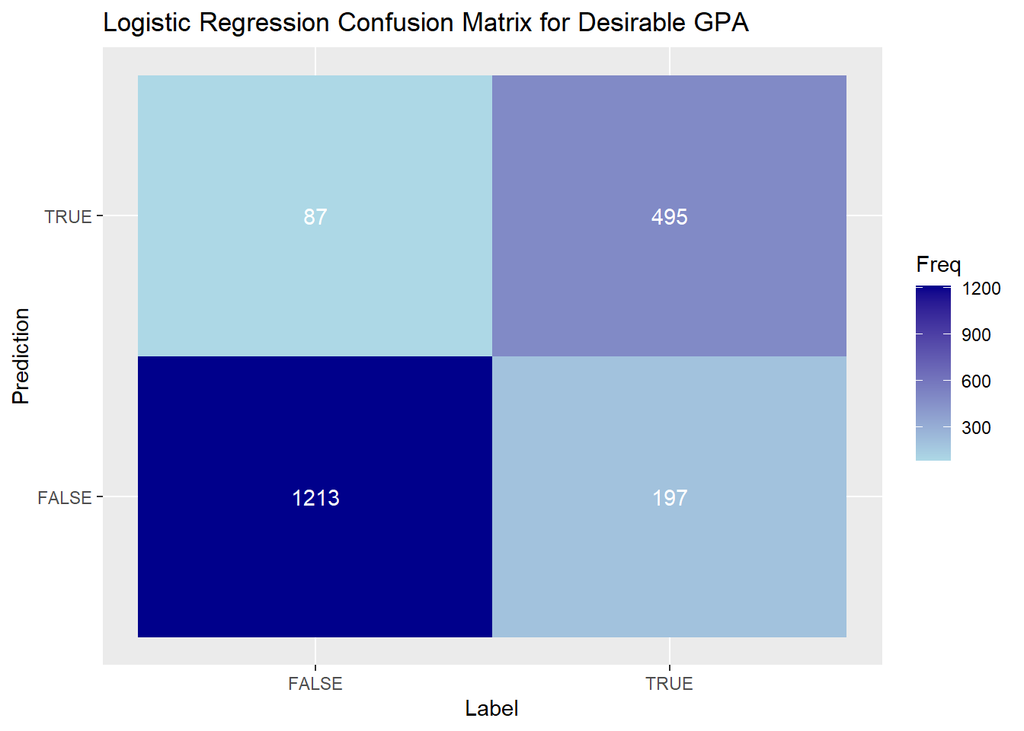

### 6.2.2 Metrics

| Metric | Score |
| --- | --- |
| Accuracy | 0.8574297 |
| Sensitivity | 0.9330769 |
| Specificity | 0.7153179 |

Based on the high accuracy of the linear classifiers, a linear decision boundary can effectively differentiate between students with a good GPA and a poor GPA. This shows that the predictors are indicative of academic performance and if students are able to improve some of the attributes, they are likely to be more successful in school.

# 7 Classification Analysis and Visualization with Tree-Based Methods and SVM

We now know that the predictors can effectively distinguish between strong and weak academic performers, but other methods may be more accurate and provide more insight into how predictions are being made.

## 7.1 Decision Tree

The decision tree is particularly useful for our case because it is interpretable, and we want to show what predictive variables are causing students to perform well in school.

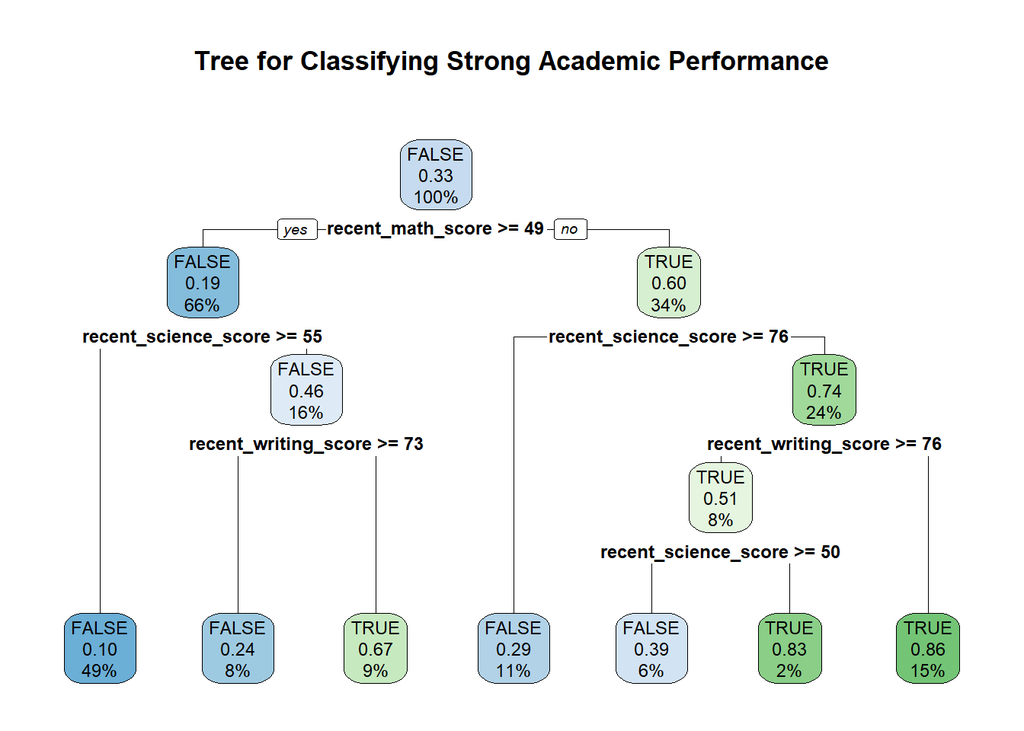

The decison tree with splits based on information gain heavily favours academic scores for determining student performance. Among them, it considers math the most significant split with the highest information gain. Many areas of science rely on a strong math background, which could explain why math score is the first split.

## 7.2 Random Forest

We follow up the decision tree by training a random forest. Since we are attempting to extract inference rather than maximize predictive accuracy, we do not show evaluation metrics on test data. Instead, we plot variable importance to show which predictive variables strongly considered by the random forest model.

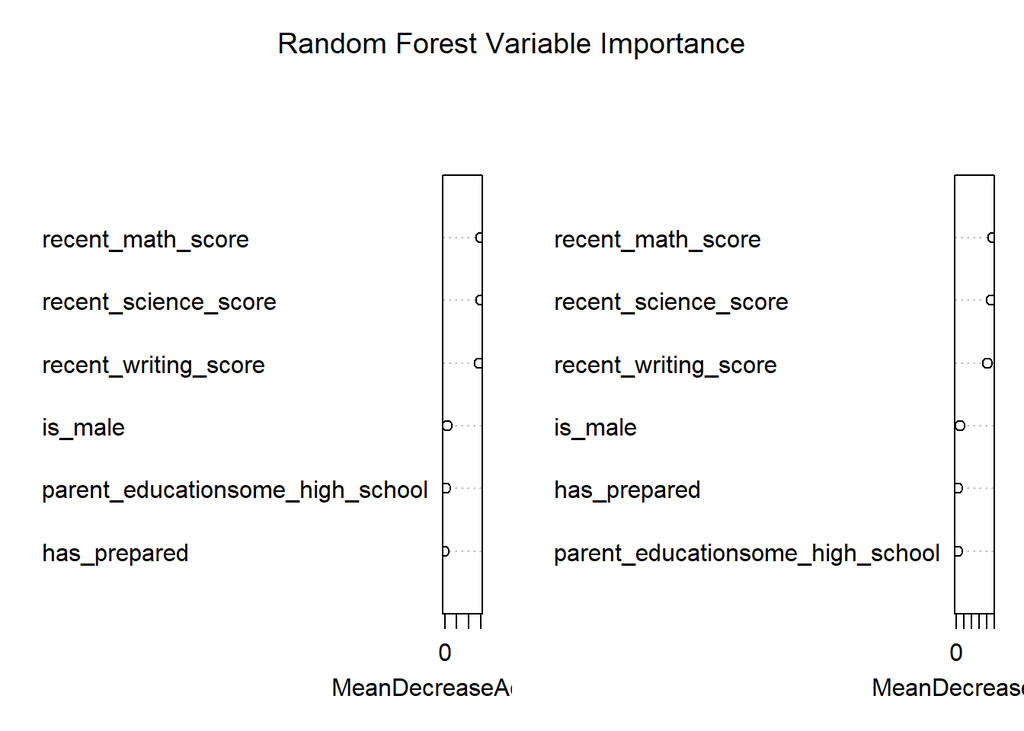

The variable importance plot strengthens the hypothesis that decision trees and random forest heavily favour the academic predictor variables.

## 7.3 SVM Kernel Analysis

We apply the kernel trick to train several support vector machines in order to analyze the ideal shape of the decision boundary.

| Kernel.Type | Misclassification |
| --- | --- |
| Linear | 0.1455823 |
| Radial | 0.1445783 |
| Quadratic | 0.3283133 |

The support vector machine with the radial kernel performs the best, followed closely by the linear kernel and distantly by the quadratic kernel. Since both linear and radial kernels perform well, two seemingly contradictory results emerge. The linear decision boundary suggests a simpler relationship between predictor variables to classify academic performers, while the strong performance of the SVM with the radial kernel suggests a more complex one. In the context of academic performance, this may mean that societal and academic predictive factors can be used in a straightforward manner to distinguish strong academic performers, but there are complex relationships between variables that are better separated with a complex decision boundary.

## 7.4 Deep Learning for Analyzing Specific GPA Scores

From analyzing different classification methods and kernels, we determined that complex relationships exist between predictors of academic success. We also previously identified that strong academic performers can be accurately identified, but specificity tends to be far worse than sensitivity. This leads us to think that certain GPA scores are being misclassified consistently, while others are being classified well. We attempt to verify the claim by creating a deep learning model with softmax activation for multiclass classification output.

```
## [1] "A  accuracy:  30.39 %"
## [1] "B  accuracy:  93.51 %"
## [1] "C  accuracy:  51.82 %"
## [1] "D  accuracy:  59.03 %"
## [1] "F  accuracy:  11.11 %"
```

# 8 Conclusions and Future Research

## 8.1 Conclusions

After completing our extensive tests, we found lots of different information that was very interesting. Firstly, we concluded that individual subject marks were identified as the strongest indicators of a student’s GPA. To expand on this point, recent scores in common subjects such as math, science, and writing were especially useful in creating a prediction.

## 8.2 Future Research

This project explored how different factors could contribute to student performance. Many more opportunities exist for expanding future research to understand a student’s success of comprehensively.

One possible research point that could be explored in the future is expanding our analysis of geographic differences. There are possibilities that geographical factors—such as schools being in urban and rural settings—that could affect the academic outcomes of students. Expanding on this analysis could provide insight on potential local challenges or advantages that some communities face.

Another future research topic could be analyzing how technology affects the performance of students. With technology becoming more prevalent in society and in classrooms, examing student access to technology as well as technology proficiency could lead to some interesting insights. If it is found that a higher proficiency in technology leads to more student success, then institutions could look to start implementing more opportunities to expose students to learning with technology.

The last point that could be researched further would be analyzing broader demographic factors of students and their families. Expanding our analysis to observe points like what languages families speak at home could possibly provide further insights on potential new correlations that affect the academic success of students. Analyzing demographic factors more thoroughly could reveal barriers and advantages that affect students that may have otherwise not been discovered.

Conducting further research to intigrate these additional factors could help further our understanding of what contributes to the academic performance of students. With this deeper knowledge, educational strategies could be designed to better support a diverse student population.